# DSA2101 Group Project

## Spotify Trend Analysis

By Group J

Name and matriculation number of team members:

| Name | Matriculation number |
| --- | --- |
| B. Nishanth | A0216347E |
| Clifton Felix | A0219735X |
| Dorothy Boyle | A0220086N |
| Srivathsan Amruth | A0220753M |
| Hari Shiman R | A0227374B |

## Introduction

Music can be enjoyed by anyone. Some find themselves drawn to the catchy beats of EDM music, while others are fascinated by the lyrical play in rap songs. Amidst this diversity in music preference, some artists receive much more success than their counterparts. The Spotify Songs dataset<sup>[[1]](https://github.com/rfordatascience/tidytuesday/tree/master/data/2020/2020-01-21)</sup> from TidyTuesday <sup>[[2]](https://github.com/rfordatascience/tidytuesday)</sup> gives us a chance to uncover trends in 2020’s music scene. We first ask which genres and subgenres receive more attention than others, then we enquire into the nature of top artists’ music to figure out what makes these artists stand out from others.

## Data Description

This dataset was taken from Spotify’s API using the R package, spotifyr. It was compiled by Charlie Thompson, Josiah Parry, Donal Phipps, and Tom Wolff in 2020. There are a total of 32833 observations and 23 variables. Each observation describes a track such as its name, id, artist, popularity, album and playlist details as well as characteristics such as energy, tempo, duration, just to name a few.

To construct the 4 graphs below, what we first did was to look at the NA values that are present (na_df) and we found that there are 5 rows where the NA is presented in track_name, track_artist,track_album_name columns. Since we require the track_artist variable for the questions we would like to answer, we removed these rows. Then, we standardize all track characteristics variables to a standard normal distribution ~ N(0, 1). After that, we corrected the capitalization for playlist_genre and playlist_subgenre. Lastly, we converted playlist_genre and playlist_subgenre columns from class strings to factor class (to show categorical variable nature via the “levels” (in factor) that are present). After the cleaning, some general statistics to note are the dataset now contains a total of 32828 observations where there are 26229 unique tracks, 10692 artists, 6 genres and 24 subgenres.

```r
library(tidyverse)
library(ggplot2)

spotify_songs = readr::read_csv('https://raw.githubusercontent.com/rfordatascience/tidytuesday/master/data/2020/2020-01-21/spotify_songs.csv')
```

```r
#Dimension of dataset before transformation and cleaning
dim(spotify_songs)
```

```
## [1] 32833    23
```

```r
# Transformation

#Standardization by mean
standardiztion = function(x) {
  (x - mean(x)) / (sd(x))
}

#Finding NA rows
na_df = spotify_songs %>% filter_all(any_vars(is.na(.)))

spotify_songs = spotify_songs %>%
  #removing NA rows
  anti_join(na_df ,by="track_id")%>%
  #standardization
  mutate(across(danceability:duration_ms, standardiztion))%>%
  #rename
  mutate(playlist_genre = recode(playlist_genre, "edm" = "EDM", "latin" = "Latin",
                                 "pop" = "Pop", "r&b" = "R&B",
                                 "rap" = "Rap", "rock" = "Rock"),
         playlist_subgenre = recode(playlist_subgenre, "big room" = "Big Room", "electro house" = "Electro House",
                                    "pop edm" = "Pop EDM", "progressive electro house" = "Progressive Electro House",
                                    "latin hip hop" = "Latin Hip Hop", "latin pop" = "Latin Pop",
                                    "reggaeton" = "Reggaeton", "tropical" = "Tropical",
                                    "dance pop" = "Dance Pop", "electropop" = "Electropop",
                                    "indie poptimism" = "Indie Poptimism", "post-teen pop" = "Post Teen Pop",
                                    "hip pop" = "Hip Pop", "neo soul" = "Neo Soul",
                                    "new jack swing" = "New Jack Swing", "urban contemporary" = "Urban Contemporary",
                                    "gangster rap" = "Gangster Rap", "hip hop" = "Hip Hop",
                                    "southern hip hop" = "Southern Hip Hop", "trap" = "Trap",
                                    "album rock" = "Album Rock", "classic rock" = "Classic Rock",
                                    "hard rock" = "Hard Rock", "permanent wave" = "Permanent Wave"),
         playlist_genre = as.factor(playlist_genre),
         playlist_subgenre = as.factor(playlist_subgenre))

# Statistics
## not using summary(spotify_songs) as we standardized

#Information about cleaned and transformed dataset
dim(spotify_songs)
```

```
## [1] 32828    23
```

```r
nrow(unique(spotify_songs %>% select(track_name, track_artist)))
```

```
## [1] 26229
```

```r
nrow(unique(spotify_songs %>% select(track_artist)))
```

```
## [1] 10692
```

```r
nrow(unique(spotify_songs %>% select(playlist_genre)))
```

```
## [1] 6
```

```r
nrow(unique(spotify_songs %>% select(playlist_subgenre)))
```

```
## [1] 24
```

## What is the Distribution of Popularity among Genres and their Respective Subgenres?

### Introduction

The question we would like to answer is “what is the distribution of popularity among genres and their respective subgenres?”. As we are interested in the distribution of all the genres and subgenres, the parts of the dataset that are necessary, in terms of columns, would be track_id, track_popularity, playlist_genre, and playlist_subgenre, and in terms of rows, we filter out duplicate rows (if there are any). We are interested in this question because we would like to see how the genres and subgenres of a track may affect its popularity, as well as check whether any particular genre dominates the music industry as of 2020. If presented with any unexpected pattern in any of the distributions, we hope that it would give us new insights into the music industry and expand our knowledge about the impact of genre/subgenre labels.

### Methodology

The first visualization is a collection of 6 histograms that plots the number of tracks against popularity score in each of the 6 genres in the dataset (using facet_wrap). This visualization utilizes 3 variables: track_id, track_popularity, and playlist_genre in the process; however, in the final graph, we exclude track_id variable as it is only used to calculate the number of tracks for the histogram (y axis). We also add two helper lines, “mean” and “hugely popular threshold”, to aid in the explanation and compare trends across genres. We believe that histogram graphs are the most suitable plot type as track_popularity variable is discrete (0 - 100) and we want to see the distribution of the number of tracks against track_popularity from 0 to 100 as the x axis. Furthermore, as the actual distribution is skewed to the right due to the large number of tracks with track_popularity = 0, for each histogram, we converted the y axis to a log scale to compress the skewness towards large values and display a wide range of values (compressing variance) in a more compact and readable manner.

For further analysis of the question, we constructed violin graphs for each of the 24 subgenres’ distribution and grouped them by their respective genre (using facet_wrap(~playlist_genre)) to show the distribution of track_popularity for all subgenres and how subgenres affect their respective genres. This visualization uses 4 variables: track_id, track_popularity, playlist_genre, and playlist_subgenre in its construction; however, similar to the first visualization, we do not display track_id variable in the final graph as it is only used for the weights in the violin graphs. In each violin graph, we also add a black dot, describing the 25th percentile of the distribution, to aid in the explanation and compare trends across subgenres. We chose violin graphs because they not only convey the general trend of each subgenre in a readable manner that allows for ease of comparison with other subgenres, but, as opposed to boxplots, also are able to visualize multimodal distributions – an indication that the sample contains several patterns of response or extreme views, preferences, or attitudes.

### Visualizations

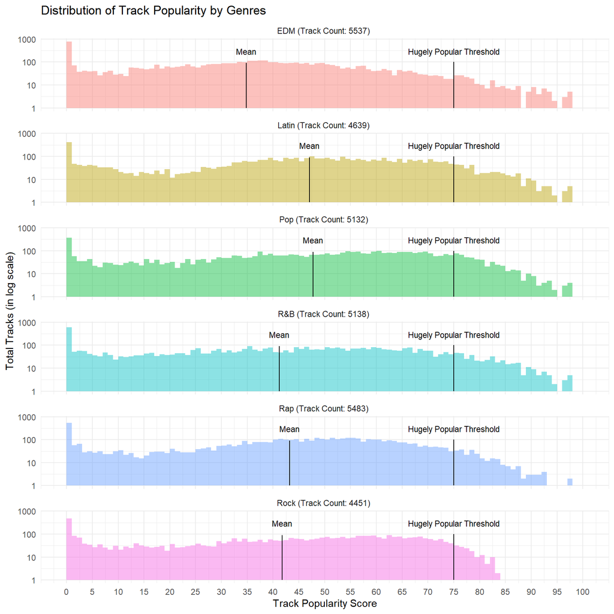

```r
histogram_df = spotify_songs %>%
  select(track_id, track_popularity, playlist_genre) %>%
  distinct()

genre_labels = histogram_df %>%
  group_by(playlist_genre) %>%
  summarise(count = n()) %>%
  #Adding label names for visulisation
  mutate(label = paste(playlist_genre, " (Track Count: ", count, ") ",sep = ""))

#Getting labels as a vector
playlist_genre.labs = genre_labels %>%
  pull(label)

#Getting label names as a vector
names(playlist_genre.labs) = genre_labels %>%
  pull(playlist_genre)

genres_mean = spotify_songs %>%
  group_by(playlist_genre) %>%
  summarize("mean" = mean(track_popularity, na.rm = TRUE))

histogram_plot = histogram_df %>%
  ggplot(aes(x = track_popularity)) +
  geom_histogram(aes(fill = playlist_genre), boundary = 0, alpha = 0.45, binwidth = 1, show.legend = FALSE) +
  #Creating 'Mean' lines
  geom_segment(data = genres_mean, aes(x = mean, y = 1, xend = mean, yend = 90)) +
  geom_text(data = genres_mean, aes(x = mean, y = 300), label = "Mean", size = 3) +
  #Creating 'Hugely Popular Threshold' lines
  geom_segment(data = genres_mean, aes(x = 75, y = 1, xend = 75, yend = 100)) +
  geom_text(data = genres_mean, aes(x = 75, y = 300), label = "Hugely Popular Threshold", size = 3) +
  #Split Visualization based on genre and labeling it accordingly
  facet_wrap(~playlist_genre,
             ncol = 1,
             labeller = labeller(playlist_genre = playlist_genre.labs)) +
  #log scaling y axis
  scale_y_log10() +
  scale_x_continuous(breaks = seq(0, 100, by = 5)) +
  ylab("Total Tracks (in log scale)") +
  xlab("Track Popularity Score") +
  labs(title = "Distribution of Track Popularity by Genres") +
  theme_minimal()

histogram_plot
```

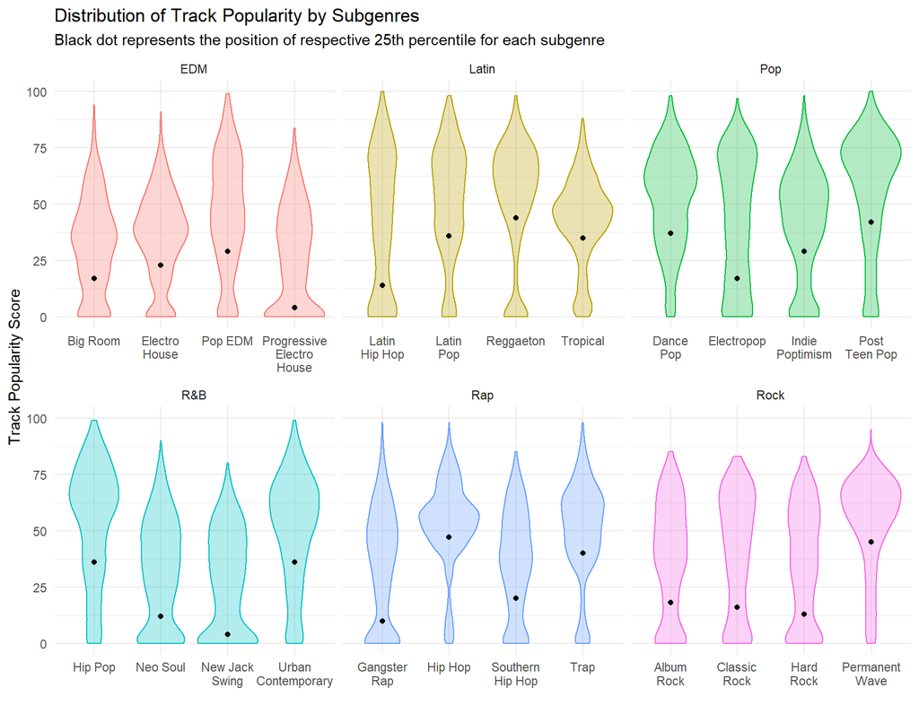

```r
subgenre_25th = spotify_songs %>%
  group_by(playlist_subgenre) %>%
  summarize("25th" = quantile(track_popularity, c(0.25), na.rm = TRUE))

violin_df = spotify_songs %>%
  select(track_id, track_popularity, playlist_genre, playlist_subgenre) %>%
  distinct() %>%
  #merging two tables
  left_join(subgenre_25th)

violin_plot = violin_df %>%
  ggplot(aes(x = playlist_subgenre, y = track_popularity)) +
  geom_violin(alpha = 0.3, aes(color = playlist_genre, fill = playlist_genre), show.legend = FALSE) +
  #display 25th percentile
  geom_point(aes(y = `25th`)) +
  #Changing labels to 2 rows
  scale_x_discrete(labels = function(x) stringr::str_wrap(x, width = 8)) +
  ylab("Track Popularity Score") +
  #remove x label
  xlab("") +
  #removing legends
  theme(axis.text.x = element_text(size = 9),legend.position = "None") +
  #split by playlist_genre
  facet_wrap(~playlist_genre, scales="free_x") +
  labs(title = "Distribution of Track Popularity by Subgenres",
       subtitle = "Black dot represents the position of respective 25th percentile for each subgenre")+
  theme_minimal()

violin_plot
```

### Discussions

We want readers to see the differences and similarities among the genres’ popularity score distribution. In terms of differences: (1) using the mean line in each genre’s histogram, we can see that, on average, Pop and Latin are the most popular genres (means around 47), and EDM is the least popular genre (mean around 35), (2) Rock did not have many hugely popular tracks, which can be observed by comparing the top tail to the right of the hugely popular threshold line of Rock with the other genres (where Rock decreases sharply before 85 as opposed to the other genres). In terms of similarities, trends-wise, we can see that all the genres have a similar distribution: (1) a general increase as popularity approaches the mean value, (2) a steep fall at popularity > 75 (there exist only few hugely popular tracks), (3) the domination of very unpopular tracks with “near 0” (“~0”) popularity (as seen from the surprising sharp spike at the left tail end). However, one thing not exactly obvious from the graph due to the log scale on y axis is the true number of 0-popularity tracks, which might mislead readers to think that the number of 0-popularity tracks for each genre is quite similar, when in fact, they are not (EDM has roughly twice the number of 0’s compared to Pop and Latin, but they look equal in the histograms). As the number of tracks in each genre is roughly balanced (ranging from 4451 to 5537 tracks), more 0’s leads to a lower mean; this might explain why the mean popularity of EDM is the lowest, while those for Pop and Latin are the highest.

From the second graph, we want readers to observe how each subgenre affects the popularity score distribution of its respective genre, which can be done by looking at the unique shape of the corresponding subgenre’s violin graph. Some of them have greater weight at the lower popularity score values, some are top-heavy, while others are quite equally distributed. The point inside each violin graph indicates the 25th percentile of the distribution to show the position of the lower tail of each subgenre’s distribution. By looking at the violins’ generally bulky lower tail and the placement of these 25th percentile points, one trend that we can see is that for most genres, one or two subgenres usually contribute to the domination of “~0” popularity score. However, a trend that cannot be observed from these graphs is the true number of 0-popularity tracks in each subgenre due to the smoothing function used for constructing the violin graphs, but this should not be an issue since we are focusing on the “~0” popularity tracks. Moreover, by looking at where each violin graph is the widest, we can see the peak(s) of the unimodal or multimodal distribution across subgenres. From these peaks, two trends we can observe are: (1) the subgenres in EDM have the most lower-valued popularity score peaks compared to other genres, (2) subgenres with the word “Pop” inside, regardless of the genre, have peaks in the high popularity region.

## How Similar are Top Artists’ Tracks to the General Taste of the Population?

### Introduction

The question we would like to answer is “How similar are top artists’ tracks to the general taste of the population?”. The parts of the dataset necessary for the question, in terms of columns, are track_artist, track_popularity, and several characteristics (will be described in the next section). Any repeated observations such as a track that appears on multiple playlists are discarded. This question piques our interest as we are interested in investigating whether the tracks of top artists are popular because these tracks cater to the public’s taste, or due to the artists’ unique music styles.

### Methodology

The first visualization is a set of smoothed line charts (using stat_smooth), displaying the relationship between each characteristic and track popularity (using facet_wrap). The variables we used are track_popularity as well as all track characteristics except key, mode, liveness and valence (these 4 variables do not exhibit clear popularity trends, hence will not be as useful in highlighting the trend of general public’s taste). Before producing the charts, the track characteristics values are normalized so that all variables have the same range and the final plot only requires a single vertical axis per row to minimize display clutter. As we want this visualization to display general population taste for the various characteristics, stat_smooth is an apt choice as it removes noise and leaves just the key trends for viewers to see. Moreover, portions between the curve and x-axis are shaded to further accentuate trend differences among various characteristics.

The second visualization hones in to explore the characteristics of tracks produced by the top 5 artists who have contributed more than 10 tracks to the dataset. Artists with 10 or less tracks in the dataset are excluded as it is hard to grasp the nature of these artists’ music style from just a few tracks. Also, the same 8 characteristics as before are used to allow the viewers to make direct comparisons when looking at both visualizations. We want to see the characteristics of these artists in their tracks, and detect if they are using any particular characteristic very heavily or minimally. Through comparison with the first visualization, we would also like to see if the top 5 artists’ tracks match the trends for popular tracks identified in the first visualization or if they are unique in certain ways. Since we are observing the values across 8 track characteristics, a radar plot (with facet_wrap) is highly suitable as it efficiently conveys all 8 dimensions of information on a 2-D plane for easy viewing, as opposed to other geoms which would require complex/multiple plots per artist to convey the same amount of information.

### Visualizations

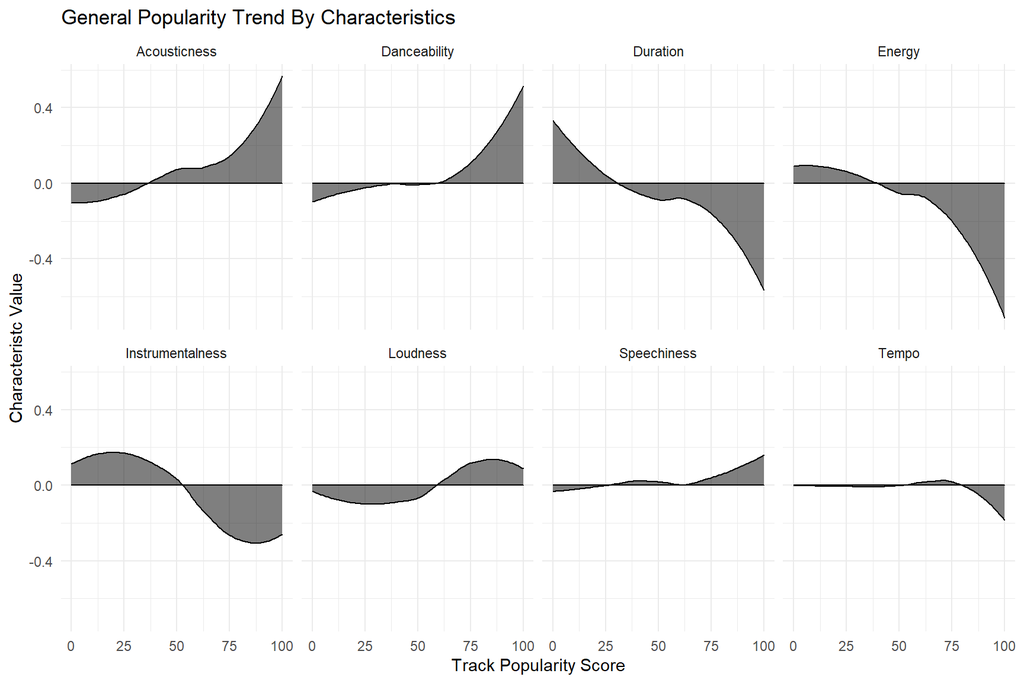

```r
smooth_df = spotify_songs %>%
  select(-c(playlist_name, playlist_id, playlist_genre, playlist_subgenre)) %>%
  distinct() %>%
  group_by(track_popularity) %>%
  #find each characteristic mean for each track_popularity
  summarize(Acousticness = mean(acousticness),
            Danceability = mean(danceability),
            Duration = mean(duration_ms),
            Energy = mean(energy),
            Instrumentalness = mean(instrumentalness),
            Loudness = mean(loudness),
            Speechiness = mean(speechiness),
            Tempo = mean(tempo)) %>%
  # put several columns into 1
  gather(Acousticness:Tempo, key = "characteristic", value = "value")

smooth_plot = smooth_df %>%
  ggplot(aes(track_popularity, value)) +
  stat_smooth(se = FALSE, geom = "area", col = 'black',
              method = 'loess', alpha = .5,
              span = 0.8, fill = 'black') +
  #split by characteristics
  facet_wrap(~characteristic, ncol = 4) +
  xlab('Track Popularity Score') +
  ylab('Characteristc Value') +
  labs(title = "General Popularity Trend By Characteristics")+
  theme_minimal()

smooth_plot
```

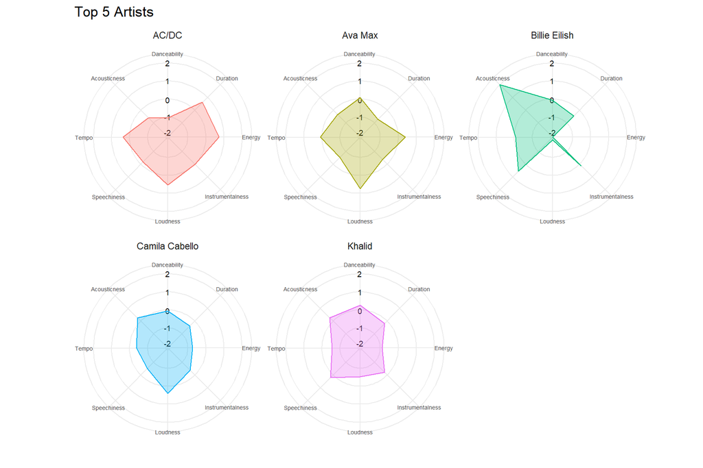

```r
rankings = spotify_songs %>%
  select(-c(playlist_name, playlist_id, playlist_genre, playlist_subgenre)) %>%
  distinct()%>%
  group_by(track_artist)%>%
  summarize(avg_score = mean(track_popularity, na.rm = TRUE),
            count = n())%>%
  filter(count > 10)%>%
  arrange(-avg_score, -count)

#find top5 from rankings (most popular with >10 songs)
top5_artist = c(rankings[1, 1], rankings[2, 1], rankings[3, 1], rankings[4, 1], rankings[5, 1])

#inheriting from CoordPolar class with our customized argument
coord_radar = function () {
  ggproto("CordRadar", CoordPolar, theta = "x", r = "y", start = -1.18,
          direction = 1,
          is_linear = function(coord) TRUE)
}

radar_df = spotify_songs %>%
  select(-c(playlist_name, playlist_id, playlist_genre, playlist_subgenre)) %>%
  distinct() %>%
  filter(track_artist %in% top5_artist) %>%
  select(track_artist, track_name, danceability:duration_ms) %>%
  group_by(track_artist) %>%
  #find characteristic mean from for each track_artist
  summarize(Acousticness = mean(acousticness),
            Danceability = mean(danceability),
            Duration = mean(duration_ms),
            Energy = mean(energy),
            Instrumentalness = mean(instrumentalness),
            Loudness = mean(loudness),
            Speechiness = mean(speechiness),
            Tempo = mean(tempo)) %>%
  #putting several columns into 1
  gather(Acousticness:Tempo, key = "characteristic", value = "value")

radar_plot = radar_df %>%
  ggplot() +
  #labeling the rings
  geom_text(x = 2, y = -0.05, aes(label = ifelse(characteristic == "Acousticness", "0", "")), size = 2.5) +
  geom_text(x = 2, y = -1, aes(label = ifelse(characteristic == "Acousticness", "-1", "")), size = 2.5) +
  geom_text(x = 2, y = 1, aes(label = ifelse(characteristic == "Acousticness", "1", "")), size = 2.5) +
  geom_text(x = 2, y = -1.85, aes(label = ifelse(characteristic == "Acousticness", "-2", "")), size = 2.5) +
  geom_text(x = 2, y = 2, aes(label = ifelse(characteristic == "Acousticness", "2", "")), size = 2.5) +
  #constructing radar plot polygons
  geom_polygon(aes(x = characteristic, y = value, group=track_artist, color = track_artist, fill = track_artist), alpha=0.3, show.legend=FALSE) +
  #converting to polar coordinates
  coord_radar() +
  xlab("") +
  ylab("") +
  #split by track_artist
  facet_wrap(~track_artist, ncol = 3)+
  labs(title ="Top 5 Artists") +
  theme_minimal() +
  theme(axis.text.x  = element_text(size = rel(0.6)), axis.text.y = element_blank())

radar_plot
```

### Discussions

From the first graph, we hope that readers can recognize popularity trends for each of the 8 track characteristics. Through the curves’ outlines, we see tracks that are better received by the public have lower than average values for duration, energy, instrumentalness and tempo, in contrast with higher than average values for acousticness, danceability, loudness, and speechiness. With the pattern shown, we made some speculations about why the trend looks the way it does, such as (1) the rise of TikTok in 2020 as a dance video-sharing app <sup>[[4]](https://www.theguardian.com/technology/2021/jun/18/bytedance-revenues-more-than-double-on-back-of-tiktok-boom)</sup> allows high danceability tracks to gain more exposure resulting in higher popularity, (2) our declining attention span over the years <sup>[[5]](https://www.theguardian.com/society/2019/apr/16/got-a-minute-global-attention-span-is-narrowing-study-reveals)</sup> has resulted in tracks with longer durations to become less popular. However, one thing not well-reflected in the graph due to the smoothed function is the deviation of some points from the general trend, but this should not be an issue as we only want to show trends of the general public taste.

From the second visualization, we hope readers can see the overall characteristics of each of these top 5 artists’ tracks and compare them with the general public’s taste. In each radar chart polygon, each vertex corresponds to the mean value for each characteristic in the artist’s tracks, and the 0-ring represents the mean value for each track characteristic in the Spotify dataset; the further the point’s distance from the 0-ring, the greater the track characteristic’s deviations from the mean. Generally, we observe that the majority of the polygon’s borders lie in the space between the 0-ring and (-1)-ring (representing values less than 1 standard deviation from the mean); hence, many of these artists’ track characteristics tend to be similar and slightly lower than the Spotify dataset’s average. However, one thing is not well-reflected in our visualization: the true value for each characteristic e.g. we see a value lying between 0-ring and (-1)-ring, but we cannot know its exact value due to the earlier-performed normalization. Although this conceals the complexity of each characteristic’s actual values, since we are only interested in how much they are used in the artists’ tracks, this should not be an issue.

Furthermore, looking into each polygon, we can better understand the characteristics of each artist’s tracks. For instance: (1) AC/DC tracks are low in acousticness and danceability, but their duration and energy are higher than average; which deviate from the trends observed in the first visualization of popular tracks being high in acousticness and danceability, but low in duration and energy. (2) for Billie Eilish’s tracks, acousticness is significantly higher (by 2 standard deviations) than the mean, whereas energy and loudness is significantly lower (by 2 standard deviations) than the mean; the exceptionally high acousticness and low energy in Billie Eilish’s tracks align with the trend for popular tracks, however, it is not the case for loudness. We speculate that (1) the 4 distinct characteristics in AC/DC tracks are their uniqueness which enabled this 1973-formed band to shine in the music industry for more than 30 years <sup>[[6]](https://en.wikipedia.org/wiki/AC/DC)</sup>, and (2) the 3 extreme characteristics in Billie Eilish tracks are Billie Eilish’s distinct musical style that sets her apart from other artists and captivates listeners <sup>[[7]](https://www.theguardian.com/music/2019/mar/29/billie-eilish-the-pop-icon-who-defines-21st-century-teenage-angst)</sup> . Similar observations can be made through the other three artists’ radar charts, where some of their tracks characteristics’ values deviate from the trends for popular tracks. We attribute these deviations to each artist’s individual musical style which, despite its differences from the general public’s taste, is still well-received, thereby placing them in the top 5.

## References

### Our Data Source

1. Charlie Thompson, Josiah Parry, Donal Phipps, and Tom Wolff (2020). Spotify Songs. https://github.com/rfordatascience/tidytuesday/tree/master/data/2020/2020-01-21
2. Thomas Mock (2022). Tidy Tuesday: A weekly data project aimed at the R ecosystem. https://github.com/rfordatascience/tidytuesday.

### Others

3. Clark, B. (2021). 30 Different Types of Rock Music (Rock Subgenres). Musician Wave. https://www.musicianwave.com/types-of-rock-music-subgenres/
4. Mark Sweney (2021). ByteDance revenues more than double on back of TikTok boom. The Guardian. https://www.theguardian.com/technology/2021/jun/18/bytedance-revenues-more-than-double-on-back-of-tiktok-boom
5. Dream McClinton (2019). Global attention span is narrowing and trends don’t last as long, study reveals. The Guardian. https://www.theguardian.com/society/2019/apr/16/got-a-minute-global-attention-span-is-narrowing-study-reveals
6. Wikipedia Editors. AC/DC. https://en.wikipedia.org/wiki/AC/DC
7. Hannah Ewens (2019). Billie Eilish: the pop icon who defines 21st-century teenage angst. The Guardian. https://www.theguardian.com/music/2019/mar/29/billie-eilish-the-pop-icon-who-defines-21st-century-teenage-angst